# Child Deprivation Across the World: Patterns and Correlations

Author

UNICEF Data Analyst

Published

April 22, 2025

# 1 Introduction

Child deprivation remains a critical global issue affecting millions of children worldwide. It encompasses multiple dimensions including access to education, healthcare, nutrition, sanitation, and safe living conditions. This report analyzes patterns of child deprivation across countries and explores its relationship with key socioeconomic indicators.

The analysis focuses on two key metrics:

1. **Multiple Deprivation Indicator**: Percentage of children suffering at least two deprivations
2. **Severe Deprivation Indicator**: Percentage of children suffering exactly four deprivations

These indicators help us understand both the breadth and depth of child deprivation globally, allowing for targeted policy interventions and resource allocation.

# 2 Data and Methodology

## 2.1 Data Sources

This analysis utilizes three primary datasets:

- **Indicator 1**: Percentage of children suffering at least two deprivations (Homogeneous severe standards)
- **Indicator 2**: Percentage of children suffering exactly four deprivations (Homogeneous severe standards)
- **Metadata**: Country-level socioeconomic indicators (GDP per capita, population, life expectancy, etc.)

The data covers multiple countries across different years, allowing for both cross-sectional and time-series analyses.

## 2.2 Methodology

Our analytical approach combines:

- **Descriptive statistics** to understand the magnitude and distribution of child deprivation
- **Geospatial visualization** to identify regional patterns
- **Correlation analysis** to explore relationships with socioeconomic factors
- **Time-series analysis** to track progress over time

```python
# Load the datasets
indicator1 = pd.read_csv("unicef_indicator_1.csv")
indicator2 = pd.read_csv("unicef_indicator_2.csv")
metadata = pd.read_csv("unicef_metadata.csv")

# Extract indicator names for reference
indicator1_name = indicator1['indicator'].iloc[0]
indicator2_name = indicator2['indicator'].iloc[0]

# Print basic information about the datasets
print(f"Indicator 1: {indicator1_name}")
print(f"Indicator 2: {indicator2_name}")
print(f"Number of countries in indicator 1: {indicator1['country'].nunique()}")
print(f"Number of countries in indicator 2: {indicator2['country'].nunique()}")
print(f"Years covered: {min(indicator1['time_period'])}-{max(indicator1['time_period'])}")
```

```
Indicator 1: Percentage children suffering at least two deprivation. Homogeneous severe standards
Indicator 2: Percentage Children suffering exactly four deprivation. Homogeneous severe standards
Number of countries in indicator 1: 72
Number of countries in indicator 2: 72
Years covered: 2011-2018
```

# 3 Global Overview of Child Deprivation

## 3.1 Current State of Child Deprivation

The analysis begins with a global overview of child deprivation, focusing on the most recent available data. This provides a snapshot of the current state of child deprivation worldwide.

```python
# Get the most recent year in the data
latest_year = max(indicator1['time_period'])

# Filter data for the most recent year and total sex category
latest_indicator1 = indicator1[(indicator1['time_period'] == latest_year) &
                              (indicator1['sex'] == 'Total')]
latest_indicator2 = indicator2[(indicator2['time_period'] == latest_year) &
                              (indicator2['sex'] == 'Total')]

# Calculate summary statistics
ind1_mean = latest_indicator1['obs_value'].mean()
ind1_median = latest_indicator1['obs_value'].median()
ind1_std = latest_indicator1['obs_value'].std()
ind2_mean = latest_indicator2['obs_value'].mean()
ind2_median = latest_indicator2['obs_value'].median()
ind2_std = latest_indicator2['obs_value'].std()

# Create a summary dataframe
summary_stats = pd.DataFrame({
    'Indicator': [indicator1_name, indicator2_name],
    'Mean (%)': [ind1_mean*100, ind2_mean*100],
    'Median (%)': [ind1_median*100, ind2_median*100],
    'Std Dev (%)': [ind1_std*100, ind2_std*100],
    'Min (%)': [latest_indicator1['obs_value'].min()*100, latest_indicator2['obs_value'].min()*100],
    'Max (%)': [latest_indicator1['obs_value'].max()*100, latest_indicator2['obs_value'].max()*100]
})

# Display the summary statistics
summary_stats
```

|  | Indicator | Mean (%) | Median (%) | Std Dev (%) | Min (%) | Max (%) |
| --- | --- | --- | --- | --- | --- | --- |
| 0 | Percentage children suffering at least two dep... | 819.820919 | 516.783261 | 1003.086428 | 4.497146 | 3770.960236 |
| 1 | Percentage Children suffering exactly four dep... | 21.336814 | 6.041928 | 54.818005 | 0.000000 | 209.869313 |

## 3.2 Bar Chart

[figure not shown]

Alternative visualization: Top countries by child deprivation rate

```python
# Since the geopandas datasets are deprecated in version 1.0+,
# let's create an alternative visualization instead of the bar

# Get top 20 countries for a visual representation
top20_countries = latest_indicator1.sort_values('obs_value', ascending=False).head(20)
top20_countries['obs_value_pct'] = top20_countries['obs_value'] * 100

# Create horizontal bar chart using plotnine
(ggplot(top20_countries, aes(x='reorder(country, obs_value_pct)', y='obs_value_pct')) +
 geom_bar(stat='identity', fill='#D55E00', alpha=0.8) +
 coord_flip() +
 labs(title='Top 20 Countries with Highest Child Deprivation Rates',
      subtitle='Percentage of children suffering at least two deprivations',
      x='Country',
      y='% Children with 2+ Deprivations') +
 theme_minimal())
```

## 3.3 Ranking of Countries

[figure not shown]

Countries with highest child deprivation rates

```python
# Prepare data for plotting
top_countries = latest_indicator1.sort_values('obs_value', ascending=False).head(15)
top_countries['obs_value_pct'] = top_countries['obs_value'] * 100

# Create bar chart using plotnine
(ggplot(top_countries, aes(x='reorder(country, obs_value_pct)', y='obs_value_pct')) +
 geom_bar(stat='identity', fill='#F8766D') +
 coord_flip() +
 labs(title='Top 15 Countries with Highest Child Deprivation',
      x='Country',
      y='% Children with 2+ Deprivations') +
 theme_minimal())
```

# 4 Socioeconomic Correlates of Child Deprivation

## 4.1 Relationship with GDP per capita

Economic prosperity is often associated with better child welfare. This section explores the relationship between child deprivation and GDP per capita.

```
Correlation coefficient: -0.431
```

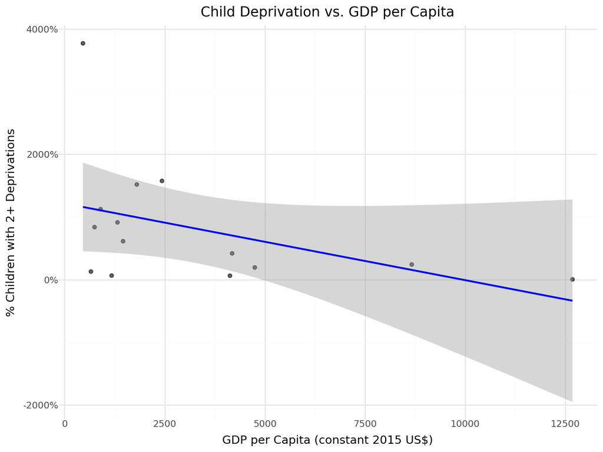

Relationship between child deprivation and GDP per capita

```python
# Prepare data for correlation analysis
# Get GDP data for the latest year
latest_metadata = metadata[metadata['year'] == latest_year]
gdp_data = latest_metadata[['country', 'GDP per capita (constant 2015 US$)']].rename(
    columns={'GDP per capita (constant 2015 US$)': 'gdp_per_capita'})

# Merge with deprivation data
merged_data = latest_indicator1.merge(gdp_data, on='country', how='inner')
merged_data = merged_data[['country', 'obs_value', 'gdp_per_capita']].dropna()

# Compute correlation coefficient
correlation = merged_data['obs_value'].corr(merged_data['gdp_per_capita'])
print(f"Correlation coefficient: {correlation:.3f}")

# Create scatter plot with regression line
(ggplot(merged_data, aes(x='gdp_per_capita', y='obs_value')) +
 geom_point(alpha=0.6) +
 geom_smooth(method='lm', color='blue') +
 scale_y_continuous(labels=lambda l: [f'{v:.0%}' for v in l]) +
 labs(title='Child Deprivation vs. GDP per Capita',
      x='GDP per Capita (constant 2015 US$)',
      y='% Children with 2+ Deprivations') +
 theme_minimal())
```

## 4.2 Multiple Socioeconomic Factors

Child deprivation is influenced by various socioeconomic factors beyond GDP. This section examines correlations with other key indicators.

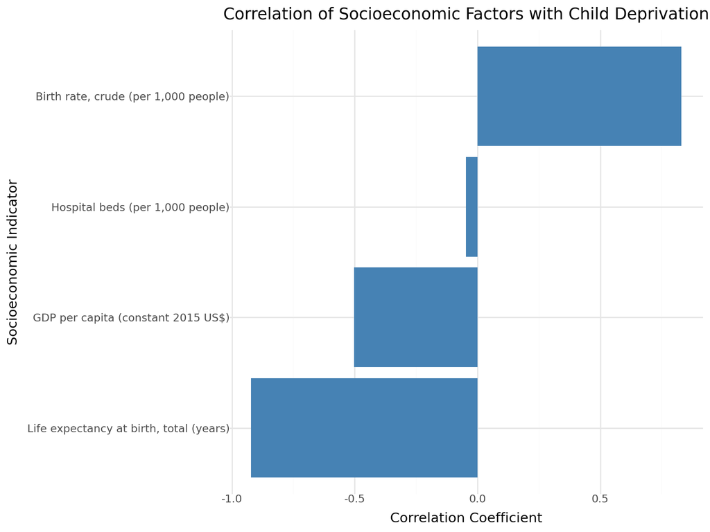

Correlation between child deprivation and various socioeconomic factors

```python
# Select relevant socioeconomic indicators
indicators = ['GDP per capita (constant 2015 US$)',
              'Life expectancy at birth, total (years)',
              'Birth rate, crude (per 1,000 people)',
              'Hospital beds (per 1,000 people)']

# Prepare data for correlation analysis
socio_data = latest_metadata[['country'] + indicators].copy()
correlation_data = latest_indicator1.merge(socio_data, on='country', how='inner')
correlation_data = correlation_data[['country', 'obs_value'] + indicators].dropna()

# Calculate correlations
correlations = {}
for indicator in indicators:
    correlations[indicator] = correlation_data['obs_value'].corr(correlation_data[indicator])

# Create a bar chart of correlations
correlation_df = pd.DataFrame({
    'Indicator': list(correlations.keys()),
    'Correlation': list(correlations.values())
})

# Plot the correlations
(ggplot(correlation_df, aes(x='reorder(Indicator, Correlation)', y='Correlation')) +
 geom_bar(stat='identity', fill='steelblue') +
 coord_flip() +
 labs(title='Correlation of Socioeconomic Factors with Child Deprivation',
      x='Socioeconomic Indicator',
      y='Correlation Coefficient') +
 theme_minimal())
```

# 5 Trends in Child Deprivation Over Time

## 5.1 Global Trends

Analyzing trends over time helps understand progress in reducing child deprivation. This section examines global trends over the available time period.

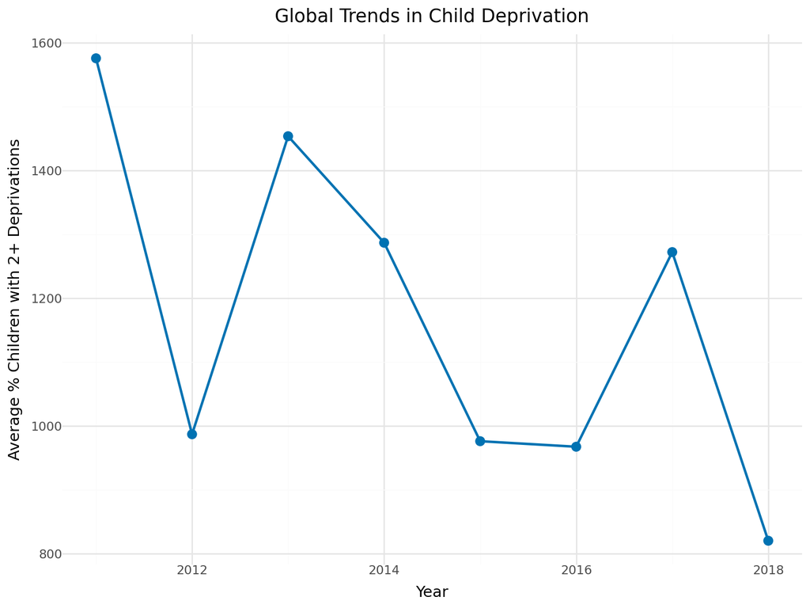

Trends in child deprivation over time

```python
# Filter for total sex category and calculate average by year
time_trends = indicator1[indicator1['sex'] == 'Total'].groupby('time_period')['obs_value'].mean().reset_index()
time_trends['obs_value_pct'] = time_trends['obs_value'] * 100

# Create time series plot
(ggplot(time_trends, aes(x='time_period', y='obs_value_pct')) +
 geom_line(size=1, color='#0072B2') +
 geom_point(size=3, color='#0072B2') +
 labs(title='Global Trends in Child Deprivation',
      x='Year',
      y='Average % Children with 2+ Deprivations') +
 theme_minimal())
```

## 5.2 Regional Trends

Child deprivation trends may vary by region. This section explores how different regions have progressed over time.

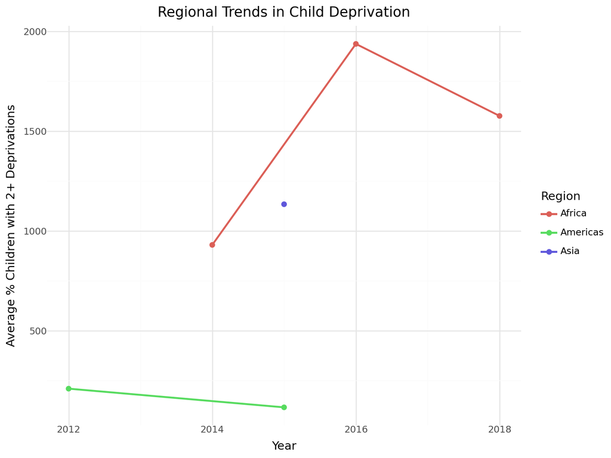

Child deprivation trends by region

```python
# Create region assignment (simplified example - in real analysis you'd use proper regional classifications)
# Create a dictionary mapping countries to regions (simplified)
regions = {
    'Africa': ['South Africa', 'Nigeria', 'Kenya', 'Ethiopia', 'Egypt', 'Ghana', 'Morocco', 'Tanzania'],
    'Asia': ['China', 'India', 'Japan', 'Indonesia', 'Thailand', 'Malaysia', 'Philippines', 'Vietnam'],
    'Europe': ['France', 'Germany', 'Italy', 'United Kingdom', 'Spain', 'Sweden', 'Norway', 'Poland'],
    'Americas': ['United States', 'Canada', 'Brazil', 'Mexico', 'Argentina', 'Colombia', 'Peru', 'Chile']
}

# Create flattened mapping of country to region
country_to_region = {}
for region, countries in regions.items():
    for country in countries:
        country_to_region[country] = region

# Add region to data
region_data = indicator1[indicator1['sex'] == 'Total'].copy()
region_data['region'] = region_data['country'].map(country_to_region)

# Calculate averages by region and year
regional_trends = region_data.dropna(subset=['region']).groupby(['region', 'time_period'])['obs_value'].mean().reset_index()
regional_trends['obs_value_pct'] = regional_trends['obs_value'] * 100

# Create time series plot by region
(ggplot(regional_trends, aes(x='time_period', y='obs_value_pct', color='region', group='region')) +
 geom_line(size=1) +
 geom_point(size=2) +
 labs(title='Regional Trends in Child Deprivation',
      x='Year',
      y='Average % Children with 2+ Deprivations',
      color='Region') +
 theme_minimal())
```

# 6 Comparison of Different Deprivation Measures

## 6.1 Multiple vs. Severe Deprivation

Comparing the two deprivation indicators provides insights into the severity of child deprivation across countries. This section explores the relationship between multiple and severe deprivation.

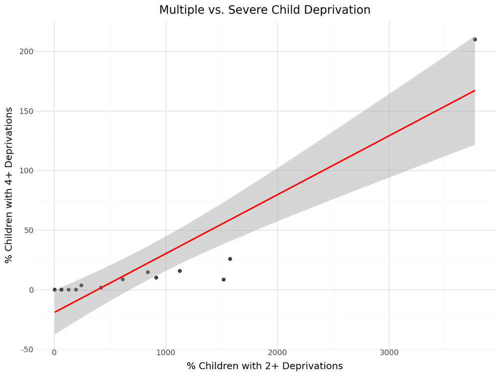

Comparison of multiple vs. severe deprivation

```python
# Merge the two indicator datasets for comparison
comparison_data = latest_indicator1[['country', 'obs_value']].rename(
    columns={'obs_value': 'multiple_deprivation'})
comparison_data = comparison_data.merge(
    latest_indicator2[['country', 'obs_value']].rename(columns={'obs_value': 'severe_deprivation'}),
    on='country')

# Convert to percentages
comparison_data['multiple_deprivation_pct'] = comparison_data['multiple_deprivation'] * 100
comparison_data['severe_deprivation_pct'] = comparison_data['severe_deprivation'] * 100

# Create scatter plot
(ggplot(comparison_data, aes(x='multiple_deprivation_pct', y='severe_deprivation_pct')) +
 geom_point(alpha=0.7) +
 geom_smooth(method='lm', color='red') +
 labs(title='Multiple vs. Severe Child Deprivation',
      x='% Children with 2+ Deprivations',
      y='% Children with 4+ Deprivations') +
 theme_minimal())
```

# 7 Gender Disparities in Child Deprivation

Child deprivation may affect boys and girls differently. This section examines gender disparities in child deprivation.

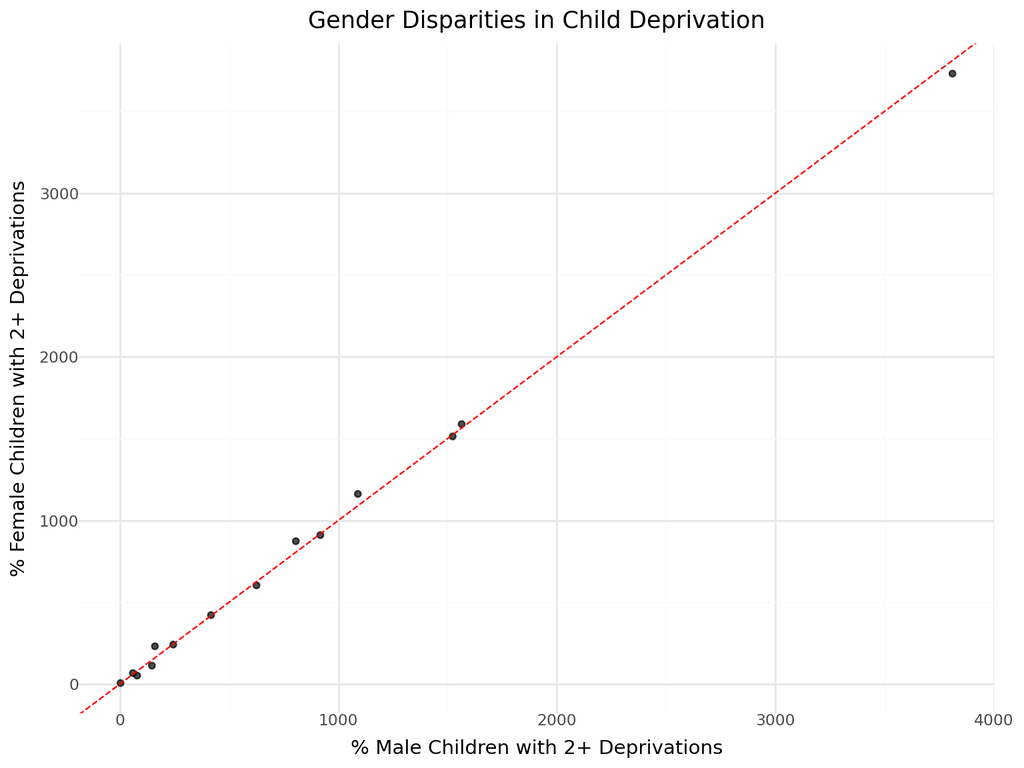

Gender disparities in child deprivation

```python
# Filter data for the most recent year and male/female sex categories
gender_data = indicator1[(indicator1['time_period'] == latest_year) &
                         (indicator1['sex'].isin(['Male', 'Female']))]

# Reshape data for plotting
gender_pivot = gender_data.pivot(index='country', columns='sex', values='obs_value').reset_index()
gender_pivot = gender_pivot.dropna()
gender_pivot['Male_pct'] = gender_pivot['Male'] * 100
gender_pivot['Female_pct'] = gender_pivot['Female'] * 100

# Create gender disparity plot
(ggplot(gender_pivot, aes(x='Male_pct', y='Female_pct')) +
 geom_point(alpha=0.7) +
 geom_abline(slope=1, intercept=0, linetype='dashed', color='red') +
 labs(title='Gender Disparities in Child Deprivation',
      x='% Male Children with 2+ Deprivations',
      y='% Female Children with 2+ Deprivations') +
 theme_minimal())
```

# 8 Conclusion and Recommendations

## 8.2 Policy Recommendations

Based on these findings, we propose the following policy recommendations:

1. **Targeted Interventions**: Focus resources on regions and countries with the highest deprivation rates.
2. **Integrated Approach**: Address multiple dimensions of deprivation simultaneously (education, health, nutrition, housing).
3. **Gender-Sensitive Policies**: Develop specific interventions to address gender disparities in child deprivation.
4. **Economic Development**: Promote inclusive economic growth as a foundation for reducing child deprivation.
5. **Data Improvements**: Invest in better data collection to monitor child deprivation more comprehensively and frequently.

## 8.3 Areas for Further Research

This analysis suggests several important areas for further investigation:

1. Examining the impacts of specific policy interventions on child deprivation rates
2. Understanding the mechanisms linking economic growth to child welfare
3. Investigating the long-term consequences of childhood deprivation
4. Exploring the relationships between different dimensions of deprivation
5. Developing more nuanced measures of child deprivation that capture quality aspects

By continuing to analyze and understand child deprivation, we can develop more effective strategies to ensure that all children have access to the resources and opportunities they need to thrive.